# Sex_differences_analysis

Miguel Alberto Pantoja-Zepeda

14/2/2023

TODO Take into account biological replicates vs replicates

```r
library(recount3)

load("~/Miguel_Github/MERS_CoV_analysis/processed_data/raw_studies.RData")
load("~/Miguel_Github/MERS_CoV_analysis/processed_data/predict_sex_studies.RData")
```

```r
names(raw_Data)
```

```
##  [1] "SRP215380" "SRP128050" "SRP199237" "SRP152324" "SRP152966" "SRP131336"
##  [7] "SRP130908" "SRP100500" "SRP125754" "SRP174174" "SRP099692"
```

```r
rse_gene_list <- raw_Data
```

# Different studies used

## Whole brain transcriptomic analysis of Tbr1-K228E mutant mice (SRP215380)

This study looked at the effects of a specific genetic mutation associated with autism in humans (TBR1-K228E) on mice. The researchers found that mice with the TBR1-K228E mutation had changes in their brain cells and behavior that are similar to those seen in humans with autism.

The study used a technique called whole brain transcriptome analysis to look at changes in gene expression in the brains of the mice. They found that the mutation led to changes in the expression of genes related to neurons, astrocytes, ribosomes, neuronal synapses, and autism risk.

In addition, the mice with the mutation showed changes in their behavior, including decreased social interaction and increased self-grooming, as well as increased anxiety-like behavior. The researchers also found abnormalities in the distribution of certain brain cells (parvalbumin-positive interneurons) and in synaptic transmission (inhibitory synaptic transmission in layer 6 pyramidal neurons).

[output not shown]

```
## $sra_attribute.age
##
## E16.5
##    15
##
## $sra_attribute.genotype
##
## Tbr1 hetero   Tbr1 homo          WT
##           5           5           5
##
## $sra_attribute.Sex
##
## female   male
##      9      6
##
## $sra_attribute.source_name
##
## Brain
##    15
##
## $sra_attribute.strain
##
## C57BL/6J
##       15
##
## $sra_attribute.tissue
##
## brain
##    15
```

```r
rse_gene_list$SRP215380$sra_attribute.genotype <-  gsub('Tbr1 hetero', 'Tbr1_+/K228E',rse_gene_list$SRP215380$sra_attribute.genotype )

rse_gene_list$SRP215380$sra_attribute.genotype <-  gsub('Tbr1 homo', 'Tbr1_K228E/K228E',rse_gene_list$SRP215380$sra_attribute.genotype )

rse_gene_list$SRP215380$sra_attribute.strain <- rep('B6', length(rse_gene_list$SRP215380$sra_attribute.strain))
```

```
## $sra_attribute.age
##
## E16.5
##    15
##
## $sra_attribute.genotype
##
##     Tbr1_+/K228E Tbr1_K228E/K228E               WT
##                5                5                5
##
## $sra_attribute.Sex
##
## female   male
##      9      6
##
## $sra_attribute.source_name
##
## Brain
##    15
##
## $sra_attribute.strain
##
## B6
## 15
##
## $sra_attribute.tissue
##
## brain
##    15
```

## (SRP128050)

This study investigated how life experiences can affect the way genes are turned on and off in the brain. The researchers focused on a protein called EGR1, which is important for memory formation, and how it interacts with another protein called TET1 to remove chemical marks on genes that can control their activity. They found that EGR1 and TET1 work together to shape the “methylome” of the brain - the chemical modifications on DNA that can control gene activity. This process is important for the brain to develop and change in response to experiences.

The study used a technique called EGR1 ChIP-seq to identify where EGR1 binds to DNA in the brain, and found that these sites become less methylated in mature neurons but remain heavily methylated in glia. The researchers also found that mice lacking either EGR1 or TET1 had similar changes in gene expression and DNA methylation patterns in the brain’s frontal cortex.

| Genotype | Effects |
| --- | --- |
| Wild-type | EGR1 recruits TET1 to shape the brain methylome during development and in response to neuronal activity. |
| Egr1 knockout | Similar changes in gene expression and DNA methylation patterns to Tet1 knockout in the brain’s frontal cortex. |
| Tet1 knockout | Similar changes in gene expression and DNA methylation patterns to Egr1 knockout in the brain’s frontal cortex. |

```
## $sra_attribute.developmental_stage
##
## P42 P55
##   2   2
##
## $sra_attribute.gender
##
## male
##    4
##
## $sra_attribute.genotype
##
## Egr1-KO Tet1-KO
##       2       2
##
## $sra_attribute.source_name
##
## Frontal cortex from 6 week old Egr1-/- mouse brain
##                                                  2
## Frontal cortex from 8 week old Tet1-/- mouse brain
##                                                  2
##
## $sra_attribute.strain
##
## B6; 129S4-Tet1tm1.1Jae/J    B6N; 129-Egr1tm1Jmi/J
##                        2                        2
##
## $`sra_attribute.tissue/cell_type`
##
## brain (frontal cortex)
##                      4
```

```r
colnames(colData(rse_gene_list$SRP128050))[colnames(colData(rse_gene_list$SRP128050)) == "sra_attribute.tissue/cell_type"] <- "sra_attribute.tissue"

colnames(colData(rse_gene_list$SRP128050))[colnames(colData(rse_gene_list$SRP128050)) == "sra_attribute.developmental_stage"] <- "sra_attribute.age"

colnames(colData(rse_gene_list$SRP128050))[colnames(colData(rse_gene_list$SRP128050)) == "sra_attribute.gender"] <- "sra_attribute.Sex"

rse_gene_list$SRP128050$sra_attribute.tissue <- rep('Frontal cortex', length(rse_gene_list$SRP128050$sra_attribute.tissue))

rse_gene_list$SRP128050$sra_attribute.strain <- rep('B6', length(rse_gene_list$SRP128050$sra_attribute.strain))


rse_gene_list$SRP128050$sra_attribute.source_name <- rep('Brain', length(rse_gene_list$SRP128050$sra_attribute.source_name))

rse_gene_list$SRP128050$sra_attribute.source_name <- rep('Brain', length(rse_gene_list$SRP128050$sra_attribute.source_name))

rse_gene_list$SRP128050$sra_attribute.genotype <-  gsub('Egr1-KO', 'Egr1_-/-',rse_gene_list$SRP128050$sra_attribute.genotype )

rse_gene_list$SRP128050$sra_attribute.genotype <-  gsub('Tet1-KO', 'Tet1_-/-',rse_gene_list$SRP128050$sra_attribute.genotype )
```

```
## $sra_attribute.age
##
## P42 P55
##   2   2
##
## $sra_attribute.Sex
##
## male
##    4
##
## $sra_attribute.genotype
##
## Egr1_-/- Tet1_-/-
##        2        2
##
## $sra_attribute.source_name
##
## Brain
##     4
##
## $sra_attribute.strain
##
## B6
##  4
##
## $sra_attribute.tissue
##
## Frontal cortex
##              4
```

## (SRP199237)

```
## $sra_attribute.age
##
## 8 months
##       90
##
## $`sra_attribute.genotype/variation`
##
## APP/PS1      WT
##      45      45
##
## $sra_attribute.Sex
##
## female   male
##     43     47
##
## $sra_attribute.source_name
##
## Whole brain
##          90
##
## $`sra_attribute.strain/background`
##
##   B6 CAST  PWK  WSB
##   22   23   23   22
##
## $sra_attribute.tissue
##
## Left brain hemisphere
##                    90
```

```r
rse_gene_list$SRP199237$sra_attribute.age <-  gsub('8 months', 'M8',rse_gene_list$SRP199237$sra_attribute.age )


colnames(colData(rse_gene_list$SRP199237))[colnames(colData(rse_gene_list$SRP199237)) == "sra_attribute.strain/background"] <- "sra_attribute.strain"

colnames(colData(rse_gene_list$SRP199237))[colnames(colData(rse_gene_list$SRP199237)) == "sra_attribute.genotype/variation"] <- "sra_attribute.genotype"


rse_gene_list$SRP199237$sra_attribute.source_name <- rep('Brain', length(rse_gene_list$SRP199237$sra_attribute.source_name))

rse_gene_list$SRP199237$sra_attribute.strain <-  gsub('CAST', 'B6_CAST',rse_gene_list$SRP199237$sra_attribute.strain )
rse_gene_list$SRP199237$sra_attribute.strain<-  gsub('PWK', 'B6_PWK',rse_gene_list$SRP199237$sra_attribute.strain )
rse_gene_list$SRP199237$sra_attribute.strain <-  gsub('WSB', 'B6_WSB',rse_gene_list$SRP199237$sra_attribute.strain )
```

```
## $sra_attribute.age
##
## M8
## 90
##
## $sra_attribute.genotype
##
## APP/PS1      WT
##      45      45
##
## $sra_attribute.Sex
##
## female   male
##     43     47
##
## $sra_attribute.source_name
##
## Brain
##    90
##
## $sra_attribute.strain
##
##      B6 B6_CAST  B6_PWK  B6_WSB
##      22      23      23      22
##
## $sra_attribute.tissue
##
## Left brain hemisphere
##                    90
```

## (SRP152324)

This project used RNA sequencing to study the molecular basis of miR-7 and miR-17-92 regulation in the POMC neuron and sex-differential expression of genes in the arcuate nucleus. The researchers found that these microRNAs are expressed in proopiomelanocortin (POMC)-expressing neurons in the mouse ARC, and that specific knockdown or knockout of these microRNAs affects diet-induced obesity in a sex-specific manner. They also identified target genes that show sex-differential expression in the ARC and respond to high-fat diet treatment. RNA sequencing was performed on ARC tissues from male miR-17-92 knockout mice, female miR-7-sponge mice, male and female wild-type mice, and the transcript abundances were estimated for each sample.

| Genotype | Effects |
| --- | --- |
| Male miR-17-92 knockout | Aggravated diet-induced obesity in males |
| Female miR-7-sponge | Aggravated diet-induced obesity in females |
| Male and female wild-type | Identified sex-differentially expressed genes in the ARC and their response to HFD |

```
## $sra_attribute.age
##
## 4 months
##        8
##
## $sra_attribute.gender
##
## female   male
##      4      4
##
## $`sra_attribute.genotype/variation`
##
## Pomc-Cre;miR-17-92flox/flox       Pomc-Cre;miR-7-sponge
##                           2                           2
##                   wild type
##                           4
##
## $sra_attribute.source_name
##
## brain
##     8
##
## $`sra_attribute.strain/background`
##
## C57BL/6
##       8
##
## $sra_attribute.tissue
##
## arcuate nucleus
##               8
```

```r
colnames(colData(rse_gene_list$SRP152324))[colnames(colData(rse_gene_list$SRP152324)) == "sra_attribute.genotype/variation"] <- "sra_attribute.genotype"

colnames(colData(rse_gene_list$SRP152324))[colnames(colData(rse_gene_list$SRP152324)) == "sra_attribute.gender"] <- "sra_attribute.Sex"

colnames(colData(rse_gene_list$SRP152324))[colnames(colData(rse_gene_list$SRP152324)) == "sra_attribute.strain/background"] <- "sra_attribute.strain"


rse_gene_list$SRP152324$sra_attribute.strain <- rep('B6', length(rse_gene_list$SRP152324$sra_attribute.strain))

rse_gene_list$SRP152324$sra_attribute.source_name <- rep('Brain', length(rse_gene_list$SRP152324$sra_attribute.source_name))

rse_gene_list$SRP152324$sra_attribute.strain <-  gsub('wild type', 'WT',rse_gene_list$SRP152324$sra_attribute.strain )


rse_gene_list$SRP152324$sra_attribute.genotype <-  gsub('Pomc-Cre;', '',rse_gene_list$SRP152324$sra_attribute.genotype )


rse_gene_list$SRP152324$sra_attribute.age <-  gsub('4 months', 'M4',rse_gene_list$SRP152324$sra_attribute.age )
```

```
## $sra_attribute.age
##
## M4
##  8
##
## $sra_attribute.Sex
##
## female   male
##      4      4
##
## $sra_attribute.genotype
##
## miR-17-92flox/flox       miR-7-sponge          wild type
##                  2                  2                  4
##
## $sra_attribute.source_name
##
## Brain
##     8
##
## $sra_attribute.strain
##
## B6
##  8
##
## $sra_attribute.tissue
##
## arcuate nucleus
##               8
```

## (SRP152966)

```
## $sra_attribute.age
##
## 7 months
##       72
##
## $sra_attribute.diet
##
##              Ad libitum every-other-day fasting                    IF12
##                      18                      18                      18
##                    IF16
##                      18
##
## $sra_attribute.source_name
##
## Brain  sham
##    71     1
##
## $sra_attribute.strain
##
## C57BL/6
##      72
##
## $sra_attribute.tissue
##
## Brain
##    72
```

```r
colnames(colData(rse_gene_list$SRP152966))[colnames(colData(rse_gene_list$SRP152966)) == "sra_attribute.genotype/variation"] <- "sra_attribute.genotype"

colnames(colData(rse_gene_list$SRP152966))[colnames(colData(rse_gene_list$SRP152966)) == "sra_attribute.strain/background"] <- "sra_attribute.strain"

colnames(colData(rse_gene_list$SRP152966))[colnames(colData(rse_gene_list$SRP152966)) == "sra_attribute.diet"] <- "sra_attribute.genotype"


rse_gene_list$SRP152966$sra_attribute.strain <- rep('B6', length(rse_gene_list$SRP152966$sra_attribute.strain))


rse_gene_list$SRP152966$sra_attribute.age <-  gsub('7 months', 'M7',rse_gene_list$SRP152966$sra_attribute.age )

rse_gene_list$SRP152966$sra_attribute.genotype <-  gsub('every-other-day ', '',rse_gene_list$SRP152966$sra_attribute.genotype )

rse_gene_list$SRP152966$sra_attribute.Sex <- rep('male', length(rse_gene_list$SRP152966$sra_attribute.strain))
```

```
## $sra_attribute.age
##
## M7
## 72
##
## $sra_attribute.genotype
##
## Ad libitum    fasting       IF12       IF16
##         18         18         18         18
##
## $sra_attribute.source_name
##
## Brain  sham
##    71     1
##
## $sra_attribute.strain
##
## B6
## 72
##
## $sra_attribute.tissue
##
## Brain
##    72
##
## $sra_attribute.Sex
##
## male
##   72
```

## (SRP131336)

```
## $sra_attribute.age
##
## P25
##  12
##
## $`sra_attribute.genotype/variation`
##
## CHD8 Asn2373LysfsX2 heterozygote mutant                               wild type
##                                       6                                       6
##
## $sra_attribute.source_name
##
##    mutant_female_brain      mutant_male_brain wild type_female_brain
##                      3                      3                      3
##   wild type_male_brain
##                      3
##
## $sra_attribute.strain_background
##
## C57BL/6
##      12
##
## $sra_attribute.tissue
##
## brain; hippocampus
##                 12
```

```r
colnames(colData(rse_gene_list$SRP131336))[colnames(colData(rse_gene_list$SRP131336)) == "sra_attribute.genotype/variation"] <- "sra_attribute.genotype"

colnames(colData(rse_gene_list$SRP131336))[colnames(colData(rse_gene_list$SRP131336)) == "sra_attribute.strain_background"] <- "sra_attribute.strain"

colnames(colData(rse_gene_list$SRP131336))[colnames(colData(rse_gene_list$SRP131336)) == "sra_attribute.diet"] <- "sra_attribute.genotype"


rse_gene_list$SRP131336$sra_attribute.tissue <- rep('Hippocampus', length(rse_gene_list$SRP131336$sra_attribute.tissue))

rse_gene_list$SRP131336$sra_attribute.strain <- rep('B6', length(rse_gene_list$SRP131336$sra_attribute.strain))
rse_gene_list$SRP131336$sra_attribute.Sex <- rse_gene_list$SRP131336$sra_attribute.source_name
rse_gene_list$SRP131336$sra_attribute.Sex <-  gsub('wild type_', '',rse_gene_list$SRP131336$sra_attribute.Sex )
rse_gene_list$SRP131336$sra_attribute.Sex <-  gsub('mutant_', '',rse_gene_list$SRP131336$sra_attribute.Sex )
rse_gene_list$SRP131336$sra_attribute.Sex <-  gsub('_brain', '',rse_gene_list$SRP131336$sra_attribute.Sex )

rse_gene_list$SRP131336$sra_attribute.source_name <- rep('Brain', length(rse_gene_list$SRP131336$sra_attribute.source_name))



rse_gene_list$SRP131336$sra_attribute.genotype <-  gsub('CHD8 Asn2373LysfsX2 heterozygote mutant', 'CHD8_-/N2373K',rse_gene_list$SRP131336$sra_attribute.genotype )


rse_gene_list$SRP131336$sra_attribute.genotype <-  gsub('wild type', 'WT',rse_gene_list$SRP131336$sra_attribute.genotype )
```

```
## $sra_attribute.age
##
## P25
##  12
##
## $sra_attribute.genotype
##
## CHD8_-/N2373K            WT
##             6             6
##
## $sra_attribute.source_name
##
## Brain
##    12
##
## $sra_attribute.strain
##
## B6
## 12
##
## $sra_attribute.tissue
##
## Hippocampus
##          12
##
## $sra_attribute.Sex
##
## female   male
##      6      6
```

## (SRP130908)

```
## $sra_attribute.generation
##
## F1 F2
## 10 10
##
## $sra_attribute.source_name
##
## Brain
##    20
##
## $sra_attribute.strain
##
## C57B6
##    20
##
## $sra_attribute.tissue
##
## Amygdala
##       20
##
## $sra_attribute.treatment
##
## no stress    stress
##        10        10
```

```r
rse_gene_list$SRP130908$sra_attribute.genotype <- paste(rse_gene_list$SRP130908$sra_attribute.generation,rse_gene_list$SRP130908$sra_attribute.treatment, sep='_')


rse_gene_list$SRP130908$sra_attribute.strain <- rep('B6', length(rse_gene_list$SRP130908$sra_attribute.strain))

rse_gene_list$SRP130908$sra_attribute.Sex <- rep('unknown', length(rse_gene_list$SRP130908$sra_attribute.strain))


rse_gene_list$SRP130908$sra_attribute.genotype <-  gsub('wild type', 'WT',rse_gene_list$SRP130908$sra_attribute.genotype )

colData(rse_gene_list$SRP130908) <- subset(colData(rse_gene_list$SRP130908), select = -c(sra_attribute.generation, sra_attribute.treatment))

rse_gene_list$SRP130908$sra_attribute.age <- rep('unknown', length(rse_gene_list$SRP130908$sra_attribute.source_name))
```

```
## $sra_attribute.source_name
##
## Brain
##    20
##
## $sra_attribute.strain
##
## B6
## 20
##
## $sra_attribute.tissue
##
## Amygdala
##       20
##
## $sra_attribute.genotype
##
## F1_no stress    F1_stress F2_no stress    F2_stress
##            5            5            5            5
##
## $sra_attribute.Sex
##
## unknown
##      20
##
## $sra_attribute.age
##
## unknown
##      20
```

## (SRP100500)

```
## $sra_attribute.cell_type
##
## neural progenitor cells             tumor cells
##                      15                       7
##
## $sra_attribute.genotype
##
##                         H3.3K27M O/E; Trp53-/-
##                                              1
##             H3.3K27M O/E; Trp53-/-; Atrx shRNA
##                                              7
## H3.3K27M O/E; Trp53-/-; Atrx shRNA; Pdgfra O/E
##                                              5
##               H3.3WT O/E; Trp53-/-; Atrx shRNA
##                                              4
##                                     Pdgfra O/E
##                                              3
##                                      wild type
##                                              2
##
## $sra_attribute.source_name
##
## Brain
##    22
##
## $sra_attribute.strain
##
## C57BL/6
##      22
##
## $sra_attribute.tissue
##
## brain
##    22
##
## $sra_attribute.tumor_status
##
## preneoplastic         tumor
##            15             7
```

```r
rse_gene_list$SRP100500$sra_attribute.tissue <- rse_gene_list$SRP100500$sra_attribute.cell_type

rse_gene_list$SRP100500$sra_attribute.strain <- rep('B6', length(rse_gene_list$SRP100500$sra_attribute.strain))


rse_gene_list$SRP100500$sra_attribute.genotype <-  gsub('wild type', 'WT',rse_gene_list$SRP100500$sra_attribute.genotype )

rse_gene_list$SRP100500$sra_attribute.genotype <-  gsub(' ', '',rse_gene_list$SRP100500$sra_attribute.genotype )


colData(rse_gene_list$SRP100500) <- subset(colData(rse_gene_list$SRP100500), select = -c(sra_attribute.cell_type, sra_attribute.tumor_status))

rse_gene_list$SRP100500$sra_attribute.Sex <- rep('unknown', length(rse_gene_list$SRP100500$sra_attribute.strain))


rse_gene_list$SRP100500$sra_attribute.age <- rse_gene_list$SRP100500$sra_attribute.tissue

rse_gene_list$SRP100500$sra_attribute.age <-  gsub('neural progenitor cells', 'E_?',rse_gene_list$SRP100500$sra_attribute.age )
rse_gene_list$SRP100500$sra_attribute.age <-  gsub('tumor cells', 'M5-9',rse_gene_list$SRP100500$sra_attribute.age )

rse_gene_list$SRP100500$sra_attribute.tissue <-  gsub('tumor cells', 'tumor',rse_gene_list$SRP100500$sra_attribute.tissue )
```

```
## $sra_attribute.genotype
##
##                     H3.3K27MO/E;Trp53-/-
##                                        1
##           H3.3K27MO/E;Trp53-/-;AtrxshRNA
##                                        7
## H3.3K27MO/E;Trp53-/-;AtrxshRNA;PdgfraO/E
##                                        5
##             H3.3WTO/E;Trp53-/-;AtrxshRNA
##                                        4
##                                PdgfraO/E
##                                        3
##                                       WT
##                                        2
##
## $sra_attribute.source_name
##
## Brain
##    22
##
## $sra_attribute.strain
##
## B6
## 22
##
## $sra_attribute.tissue
##
## neural progenitor cells                   tumor
##                      15                       7
##
## $sra_attribute.Sex
##
## unknown
##      22
##
## $sra_attribute.age
##
##  E_? M5-9
##   15    7
```

## (SRP125754)

```
## $sra_attribute.agent
##
##                                      100ug mAb/Dose
##                                                   3
##                                      200ug mAb/Dose
##                                                   3
##                                       50ug mAb/Dose
##                                                   3
##                GL261 tumor tissue, No treat control
##                                                   2
## GL261 tumor tissue, VEGF-A blockade,200ug mAb/ dose
##                                                   1
##                               Healthy brain control
##                                                   3
##
## $sra_attribute.source_name
##
##                                             C57BL/6
##                                                   6
##                GL261 tumor tissue, No treat control
##                                                   1
## GL261 tumor tissue, VEGF-A blockade,100ug mAb/ dose
##                                                   3
## GL261 tumor tissue, VEGF-A blockade,200ug mAb/ dose
##                                                   2
##  GL261 tumor tissue, VEGF-A blockade,50ug mAb/ dose
##                                                   3
##
## $sra_attribute.strain
##
##   Brain tumor       C57BL/6 Healthy Brain
##             3             9             3
##
## $sra_attribute.tissue
##
##                                         Brain tumor
##                                                   9
##                GL261 tumor tissue, No treat control
##                                                   2
## GL261 tumor tissue, VEGF-A blockade,200ug mAb/ dose
##                                                   1
##                               Healthy brain control
##                                                   3
```

```r
colData(rse_gene_list$SRP125754)[colData(rse_gene_list$SRP125754)$sra_attribute.tissue=='Healthy brain control', c('sra_attribute.strain','sra_attribute.source_name','sra_attribute.agent'
)]
```

```
## DataFrame with 3 rows and 3 columns
##            sra_attribute.strain sra_attribute.source_name   sra_attribute.agent
##                     <character>               <character>           <character>
## SRR6326643        Healthy Brain                   C57BL/6 Healthy brain control
## SRR6326644        Healthy Brain                   C57BL/6 Healthy brain control
## SRR6326645        Healthy Brain                   C57BL/6 Healthy brain control
```

```r
colData(rse_gene_list$SRP125754)[colData(rse_gene_list$SRP125754)$sra_attribute.tissue=='Healthy brain control', c('sra_attribute.genotype')] <- rep('WT', sum(colData(rse_gene_list$SRP125754)$sra_attribute.tissue=='Healthy brain control'))
```

```r
colData(rse_gene_list$SRP125754)[colData(rse_gene_list$SRP125754)$sra_attribute.tissue=='Brain tumor', c('sra_attribute.strain','sra_attribute.source_name','sra_attribute.agent'
)]
```

```
## DataFrame with 9 rows and 3 columns
##            sra_attribute.strain sra_attribute.source_name sra_attribute.agent
##                     <character>               <character>         <character>
## SRR6326648              C57BL/6    GL261 tumor tissue, ..       50ug mAb/Dose
## SRR6326649              C57BL/6    GL261 tumor tissue, ..       50ug mAb/Dose
## SRR6326650              C57BL/6    GL261 tumor tissue, ..       50ug mAb/Dose
## SRR6326651              C57BL/6    GL261 tumor tissue, ..      100ug mAb/Dose
## SRR6326652              C57BL/6    GL261 tumor tissue, ..      100ug mAb/Dose
## SRR6326653              C57BL/6    GL261 tumor tissue, ..      100ug mAb/Dose
## SRR6326654              C57BL/6    GL261 tumor tissue, ..      200ug mAb/Dose
## SRR6326655              C57BL/6    GL261 tumor tissue, ..      200ug mAb/Dose
## SRR6326656              C57BL/6    GL261 tumor tissue, ..      200ug mAb/Dose
```

```r
colData(rse_gene_list$SRP125754)[colData(rse_gene_list$SRP125754)$sra_attribute.tissue=='Brain tumor', c('sra_attribute.genotype')] <- paste('Tumor', colData(rse_gene_list$SRP125754)[colData(rse_gene_list$SRP125754)$sra_attribute.tissue=='Brain tumor', c('sra_attribute.agent')] )
```

Probablemente la muestra que nos falta….

```r
colData(rse_gene_list$SRP125754)[colData(rse_gene_list$SRP125754)$sra_attribute.tissue=='GL261 tumor tissue, VEGF-A blockade,200ug mAb/ dose', c('sra_attribute.strain','sra_attribute.agent'
)]
```

```
## DataFrame with 1 row and 2 columns
##            sra_attribute.strain    sra_attribute.agent
##                     <character>            <character>
## SRR6326657          Brain tumor GL261 tumor tissue, ..
```

```r
colData(rse_gene_list$SRP125754)[colData(rse_gene_list$SRP125754)$sra_attribute.tissue=='GL261 tumor tissue, VEGF-A blockade,200ug mAb/ dose',  c('sra_attribute.genotype')] <- rep('Tumor', sum(colData(rse_gene_list$SRP125754)$sra_attribute.tissue=='GL261 tumor tissue, VEGF-A blockade,200ug mAb/ dose'))
```

```r
colData(rse_gene_list$SRP125754)[colData(rse_gene_list$SRP125754)$sra_attribute.tissue=='GL261 tumor tissue, No treat control', c('sra_attribute.strain','sra_attribute.agent'
)]
```

```
## DataFrame with 2 rows and 2 columns
##            sra_attribute.strain    sra_attribute.agent
##                     <character>            <character>
## SRR6326646          Brain tumor GL261 tumor tissue, ..
## SRR6326647          Brain tumor GL261 tumor tissue, ..
```

```r
colData(rse_gene_list$SRP125754)[colData(rse_gene_list$SRP125754)$sra_attribute.tissue=='GL261 tumor tissue, No treat control',  c('sra_attribute.genotype')] <- rep('Tumor', sum(colData(rse_gene_list$SRP125754)$sra_attribute.tissue=='GL261 tumor tissue, No treat control'))
```

```r
rse_gene_list$SRP125754$sra_attribute.Sex <- rep('unknown', length(rse_gene_list$SRP125754$sra_attribute.strain))
```

```r
rse_gene_list$SRP125754$sra_attribute.strain <- rep('B6', length(rse_gene_list$SRP125754$sra_attribute.strain))

rse_gene_list$SRP125754$sra_attribute.tissue <-  factor(tolower(rse_gene_list$SRP125754$sra_attribute.tissue))
rse_gene_list$SRP125754$sra_attribute.tissue <- factor(ifelse(rse_gene_list$SRP125754$sra_attribute.tissue == 'healthy brain control', "brain", "tumor"))

rse_gene_list$SRP125754$sra_attribute.source_name <- rep('Brain', length(rse_gene_list$SRP125754$sra_attribute.source_name))


colData(rse_gene_list$SRP125754) <- subset(colData(rse_gene_list$SRP125754), select = -c(sra_attribute.agent))

rse_gene_list$SRP125754$sra_attribute.age <- rep('unknown', length(rse_gene_list$SRP125754$sra_attribute.source_name))
```

```
## $sra_attribute.source_name
##
## Brain
##    15
##
## $sra_attribute.strain
##
## B6
## 15
##
## $sra_attribute.tissue
##
## brain tumor
##     3    12
##
## $sra_attribute.genotype
##
##                Tumor Tumor 100ug mAb/Dose Tumor 200ug mAb/Dose
##                    3                    3                    3
##  Tumor 50ug mAb/Dose                   WT
##                    3                    3
##
## $sra_attribute.Sex
##
## unknown
##      15
##
## $sra_attribute.age
##
## unknown
##      15
```

## (SRP174174)

```
## $sra_attribute.genotype
##
## Mettl14 fl/fl; Olig2-Cre             Mettl14fl/fl
##                        6                        6
##
## $sra_attribute.source_name
##
## Brain
##    12
##
## $sra_attribute.strain
##
## C57BL/6 background
##                 12
```

```r
rse_gene_list$SRP174174$sra_attribute.tissue <- rep('brain', length(rse_gene_list$SRP174174$sra_attribute.source_name))

rse_gene_list$SRP174174$sra_attribute.Sex <- rep('unknown', length(rse_gene_list$SRP174174$sra_attribute.source_name))

rse_gene_list$SRP174174$sra_attribute.strain <- rep('B6', length(rse_gene_list$SRP174174$sra_attribute.source_name))


rse_gene_list$SRP174174$sra_attribute.age <- rep('P18-P180', length(rse_gene_list$SRP174174$sra_attribute.source_name))
```

both female and male mice were used

```
## $sra_attribute.genotype
##
## Mettl14 fl/fl; Olig2-Cre             Mettl14fl/fl
##                        6                        6
##
## $sra_attribute.source_name
##
## Brain
##    12
##
## $sra_attribute.strain
##
## B6
## 12
##
## $sra_attribute.tissue
##
## brain
##    12
##
## $sra_attribute.Sex
##
## unknown
##      12
##
## $sra_attribute.age
##
## P18-P180
##       12
```

## (SRP099692)

```
## $`sra_attribute.genotype/variation`
##
##             NRAS-V12; shP53; shATRX NRAS-V12; shP53; shATRX; IDH1-R132H
##                                   5                                   7
##
## $sra_attribute.source_name
##
## Implanted glioma brain tumor
##                           12
##
## $`sra_attribute.strain/background`
##
## BL6
##  12
##
## $sra_attribute.tissue
##
## Glioma brain tumor
##                 12
##
## $sra_attribute.treatment
##
## control IR 20Gy
##       6       6
```

```r
colnames(colData(rse_gene_list$SRP099692))[colnames(colData(rse_gene_list$SRP099692)) == "sra_attribute.genotype/variation"] <- "sra_attribute.genotype"

colnames(colData(rse_gene_list$SRP099692))[colnames(colData(rse_gene_list$SRP099692)) == "sra_attribute.strain/background"] <- "sra_attribute.strain"

rse_gene_list$SRP099692$sra_attribute.genotype <- paste(rse_gene_list$SRP099692$sra_attribute.treatment, rse_gene_list$SRP099692$sra_attribute.genotype)

rse_gene_list$SRP099692$sra_attribute.tissue <- rep('tumor', length(rse_gene_list$SRP099692$sra_attribute.source_name))

rse_gene_list$SRP099692$sra_attribute.strain <- rep('B6', length(rse_gene_list$SRP099692$sra_attribute.source_name))

rse_gene_list$SRP099692$sra_attribute.source_name <- rep('Brain', length(rse_gene_list$SRP099692$sra_attribute.source_name))


rse_gene_list$SRP099692$sra_attribute.age <- rep('P42-P56', length(rse_gene_list$SRP099692$sra_attribute.source_name))

rse_gene_list$SRP099692$sra_attribute.Sex <- rep('unknown', length(rse_gene_list$SRP099692$sra_attribute.source_name))

colData(rse_gene_list$SRP099692) <- subset(colData(rse_gene_list$SRP099692), select = -c(sra_attribute.treatment))
```

Studies did not discriminate sex, and both male and females were used.

```
## $sra_attribute.genotype
##
##             control NRAS-V12; shP53; shATRX
##                                           3
## control NRAS-V12; shP53; shATRX; IDH1-R132H
##                                           3
##             IR 20Gy NRAS-V12; shP53; shATRX
##                                           2
## IR 20Gy NRAS-V12; shP53; shATRX; IDH1-R132H
##                                           4
##
## $sra_attribute.source_name
##
## Brain
##    12
##
## $sra_attribute.strain
##
## B6
## 12
##
## $sra_attribute.tissue
##
## tumor
##    12
##
## $sra_attribute.age
##
## P42-P56
##      12
##
## $sra_attribute.Sex
##
## unknown
##      12
```

# Process and Merge data

## Process

```r
normalize_data <- function(x){
  x$assigned_gene_prop <- x$recount_qc.gene_fc_count_all.assigned /     x$recount_qc.gene_fc_count_all.total
    print(summary(x$assigned_gene_prop))
x
}


rse_gene_list <- lapply(rse_gene_list, normalize_data)
```

```
##    Min. 1st Qu.  Median    Mean 3rd Qu.    Max.
##  0.7603  0.7648  0.7672  0.7676  0.7695  0.7763
##    Min. 1st Qu.  Median    Mean 3rd Qu.    Max.
##  0.8356  0.8385  0.8399  0.8412  0.8427  0.8495
##    Min. 1st Qu.  Median    Mean 3rd Qu.    Max.
##  0.7130  0.7381  0.7455  0.7445  0.7521  0.7747
##    Min. 1st Qu.  Median    Mean 3rd Qu.    Max.
##  0.3256  0.3602  0.3623  0.3658  0.3735  0.4099
##    Min. 1st Qu.  Median    Mean 3rd Qu.    Max.
##  0.8451  0.8597  0.8631  0.8630  0.8670  0.8748
##    Min. 1st Qu.  Median    Mean 3rd Qu.    Max.
##  0.7886  0.7903  0.7917  0.7924  0.7944  0.7964
##    Min. 1st Qu.  Median    Mean 3rd Qu.    Max.
##  0.7239  0.7749  0.7843  0.7805  0.7900  0.8000
##    Min. 1st Qu.  Median    Mean 3rd Qu.    Max.
##  0.6196  0.6407  0.6649  0.6625  0.6769  0.7251
##    Min. 1st Qu.  Median    Mean 3rd Qu.    Max.
##  0.6513  0.7412  0.7585  0.7568  0.7863  0.8034
##    Min. 1st Qu.  Median    Mean 3rd Qu.    Max.
##  0.7925  0.7985  0.8054  0.8135  0.8225  0.8504
##    Min. 1st Qu.  Median    Mean 3rd Qu.    Max.
##  0.6136  0.6623  0.6828  0.6766  0.7024  0.7087
```

```r
## Guardemos nuestro objeto entero por si luego cambiamos de opinión
rse_gene_unfiltered <- rse_gene_list
```

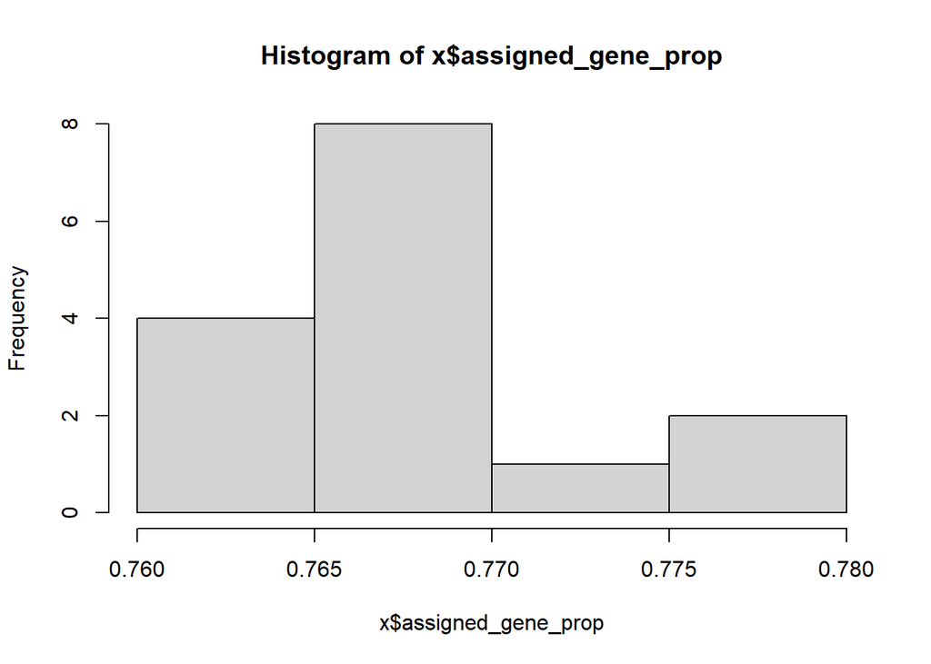

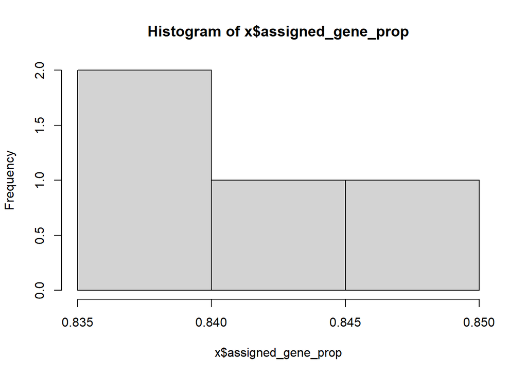

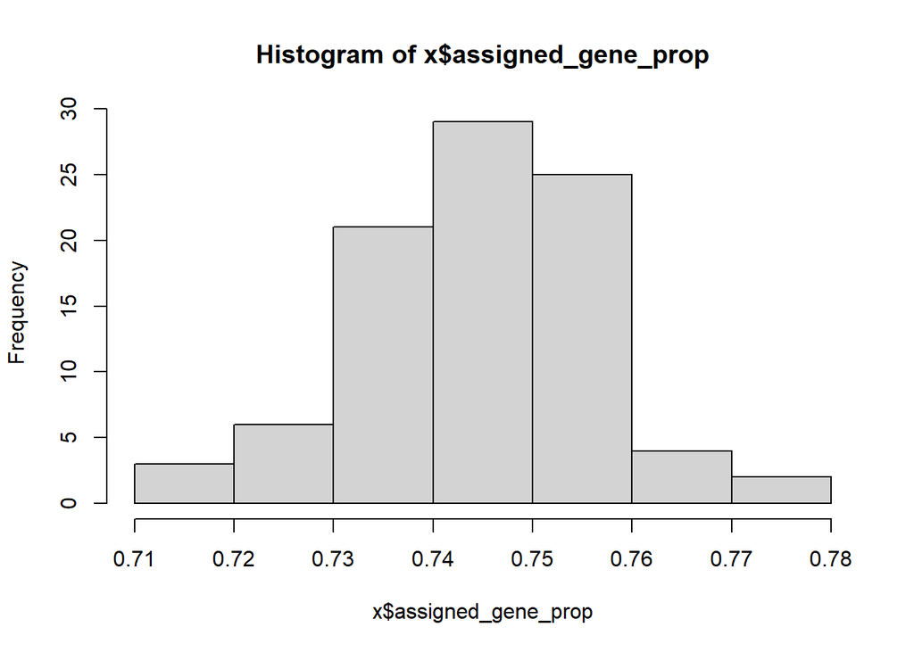

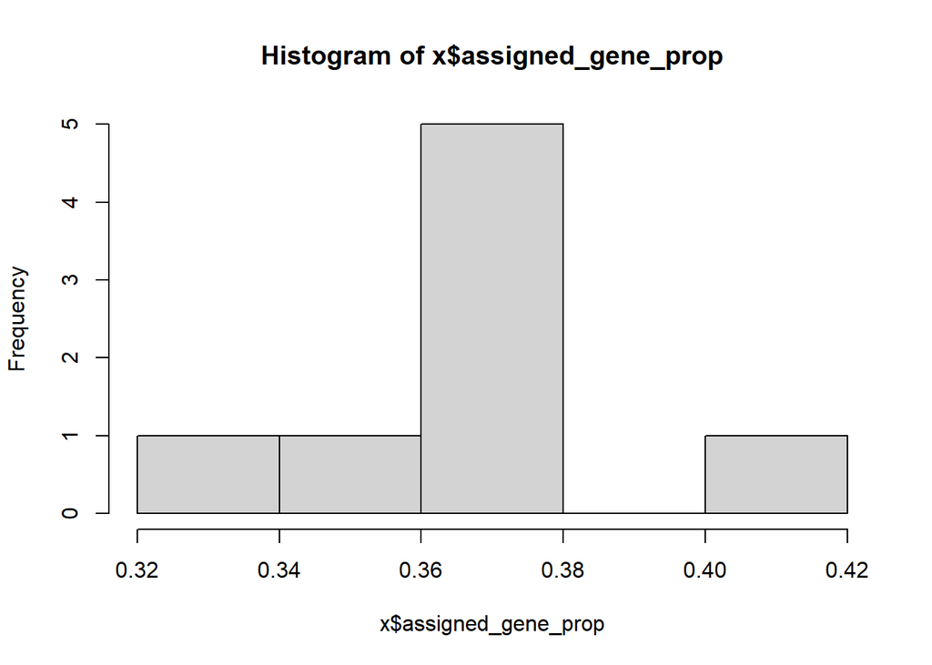

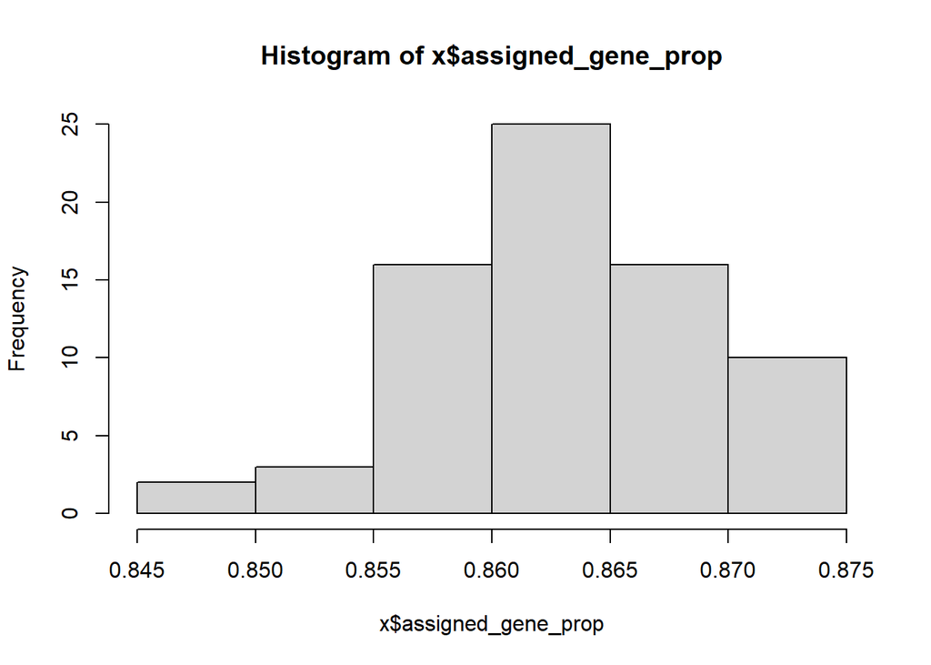

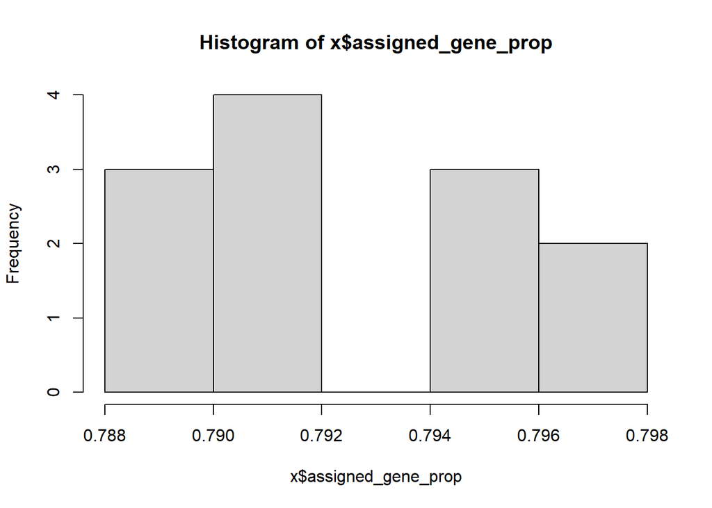

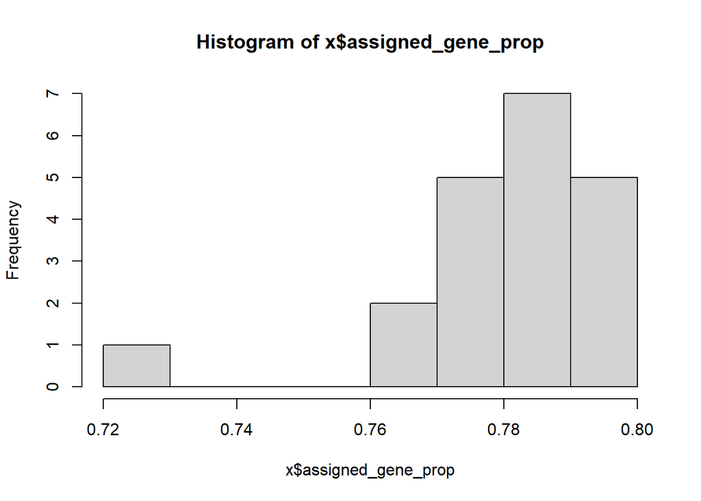

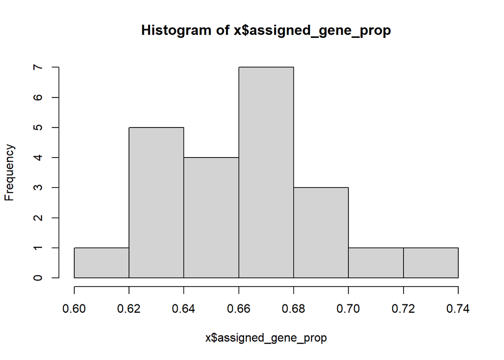

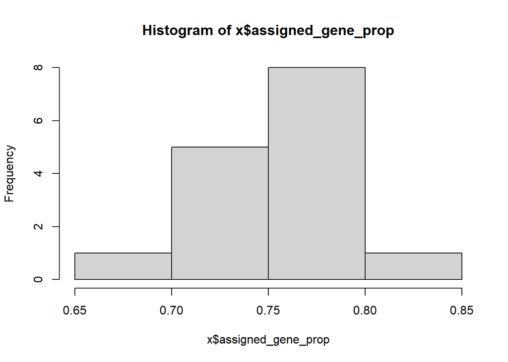

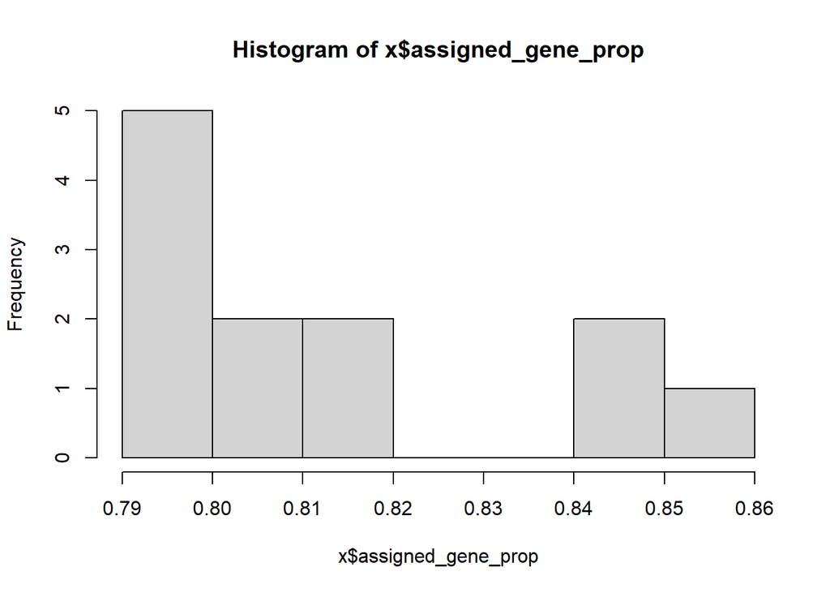

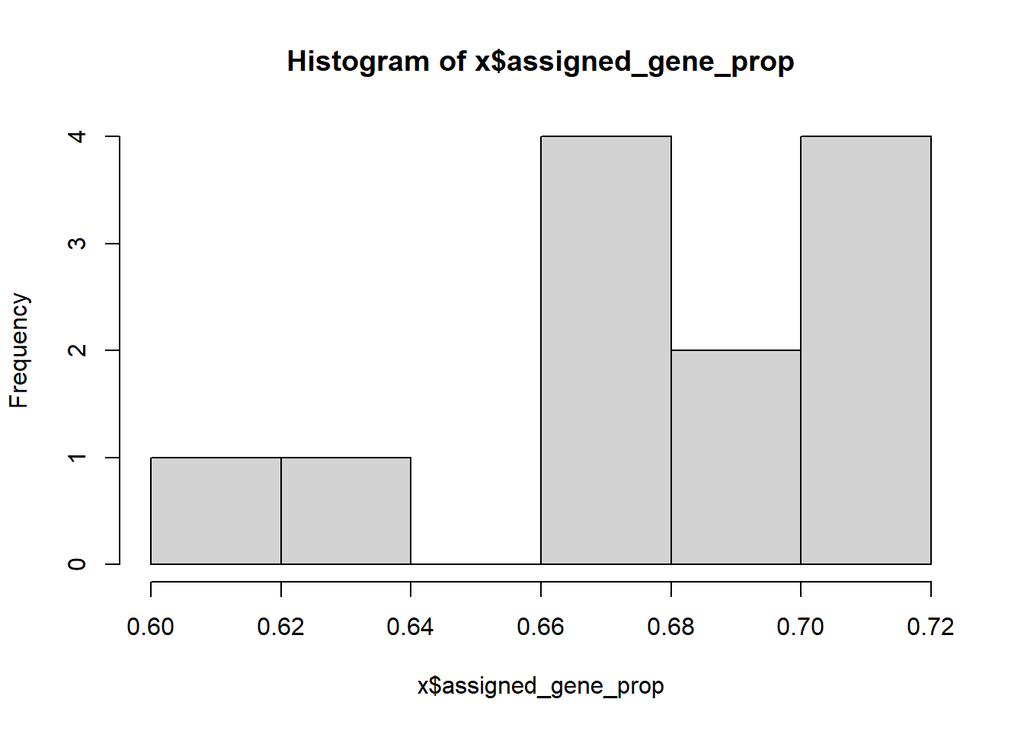

```
## $SRP215380
##
## FALSE
##    15
##
## $SRP128050
##
## FALSE
##     4
##
## $SRP199237
##
## FALSE
##    90
##
## $SRP152324
##
## FALSE
##     8
##
## $SRP152966
##
## FALSE
##    72
##
## $SRP131336
##
## FALSE
##    12
##
## $SRP130908
##
## FALSE
##    20
##
## $SRP100500
##
## FALSE
##    22
##
## $SRP125754
##
## FALSE
##    15
##
## $SRP174174
##
## FALSE
##    12
##
## $SRP099692
##
## FALSE
##    12
```

```r
# no hay menores a 0.3, pero si hubiera
rse_gene_list <- rse_gene_unfiltered
## Eliminemos a muestras malas
remove_check <- function(x){
  hist(x$assigned_gene_prop)
table(x$assigned_gene_prop < 0.3)
}

lapply(rse_gene_list, remove_check)
```

```r
remove_failures <- function(x){
  x <- x[, x$assigned_gene_prop > 0.3]
  print(x)
  gene_means <- rowMeans(assay(x, "counts"))
  summary(gene_means)
  x
}

rse_gene_list <- lapply(rse_gene_list, remove_failures)
```

[output not shown]

[output cut: 55 more lines]

```
##   ENSMUSG00000096850.1 ENSMUSG00000099871.1
## rowData names(11): source type ... havana_gene tag
## colnames(12): SRR8362467 SRR8362468 ... SRR8362477 SRR8362478
## colData names(184): rail_id external_id ... sra_attribute.age
##   assigned_gene_prop
## class: RangedSummarizedExperiment
## dim: 55421 12
## metadata(8): time_created recount3_version ... annotation recount3_url
## assays(2): raw_counts counts
## rownames(55421): ENSMUSG00000079800.2 ENSMUSG00000095092.1 ...
##   ENSMUSG00000096850.1 ENSMUSG00000099871.1
## rowData names(11): source type ... havana_gene tag
## colnames(12): SRR5258545 SRR5258546 ... SRR5258555 SRR5258556
## colData names(184): rail_id external_id ... sra_attribute.Sex
##   assigned_gene_prop
```

## Merge

```r
joined_filtered_data <- cbind(rse_gene_list$SRP215380,rse_gene_list$SRP128050,rse_gene_list$SRP199237,rse_gene_list$SRP152324, rse_gene_list$SRP152966,rse_gene_list$SRP131336,rse_gene_list$SRP130908,rse_gene_list$SRP100500,rse_gene_list$SRP125754,rse_gene_list$SRP174174,rse_gene_list$SRP099692)
```

```r
save(joined_filtered_data, file = "~/Miguel_Github/MERS_CoV_analysis/processed_data/better_curated_data.RData")
```